# Homework 3

# Exercise 2

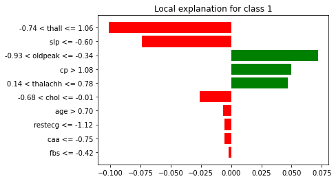

# Exercise 3

observation 0

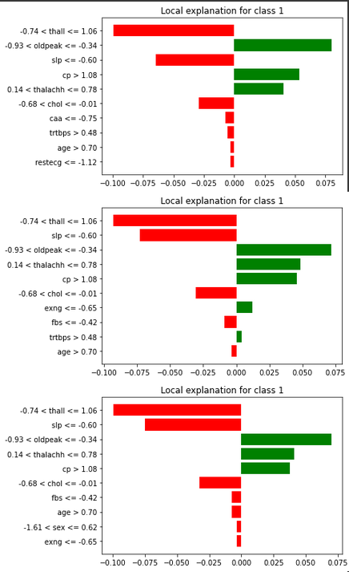

observation 1

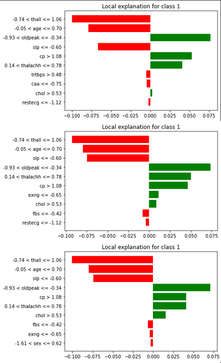

observation 2

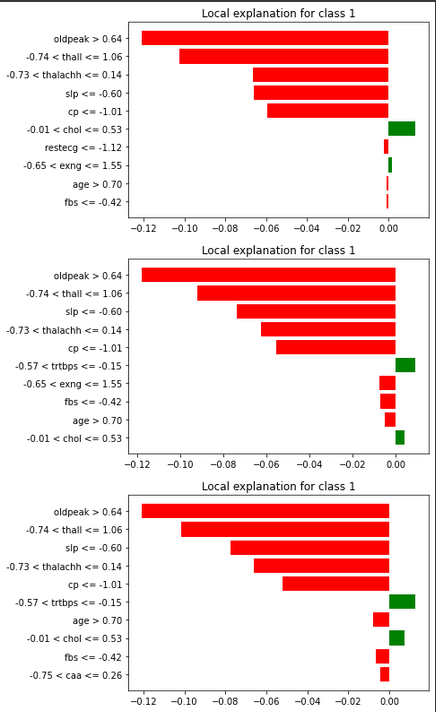

While there is *some* variability with respect to the seed, it seems that the explanations are generally stable. The attributions do not vary significantly. It is likely due to the sample size - the results would vary much more if we weren't able to simply sample randomly, e.g. not in a tabular case.

# Exercise 4

first SHAP, second LIME

observation 0

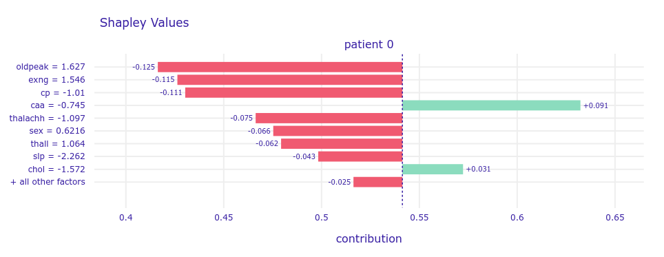

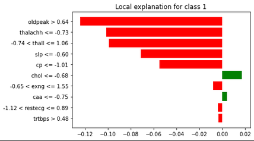

observation 1

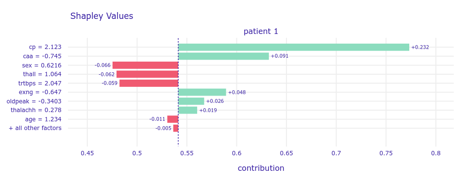

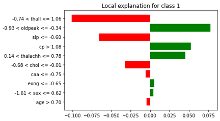

observation 2

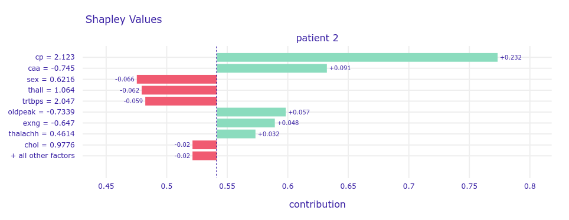

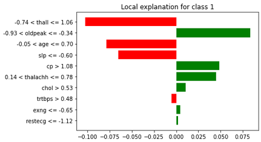

It seems that the main difference between the explanations is that SHAP often attributes larger weights to single attributes, while LIME seems more conservative, distributing the effect more smoothly across features

# Exercise 5

The original model is a Random Forest, and we're going to compare it with a Boosted Tree Model.

Top - RF Bottom - GBM

observation 0

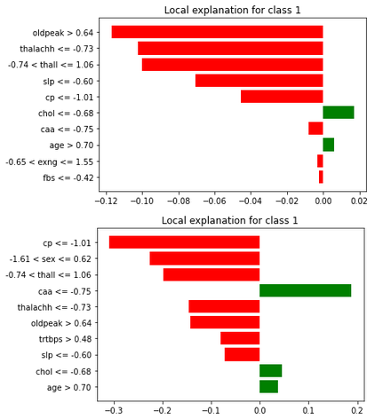

observation 1

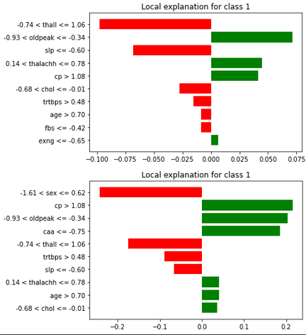

observation 2

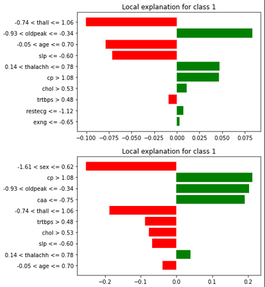

observation 3

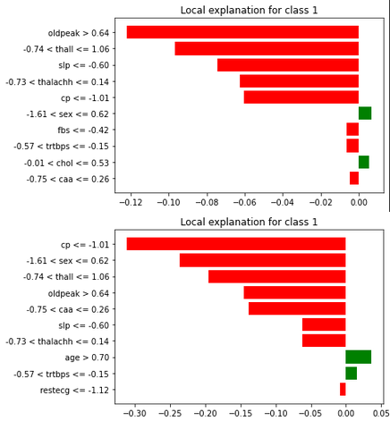

observation 4

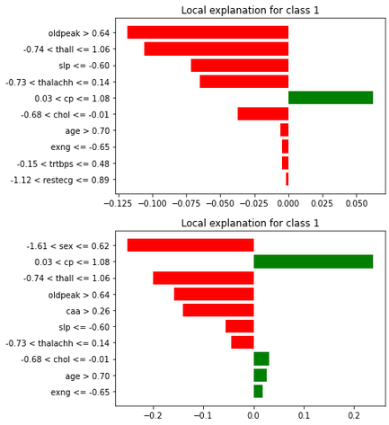

A very interesting phenomenon - the shapes of the plots are near identical, yet the two models emphasise very different attributes. Another observation - the magnitudes for GBM are much larger than for Random Forest. It seems that the learned curvatures for GBM are much "ragged", or less smooth, than those of RF.

CONCLUSION: The LIME explanations are stable for tabular data, since we can sample to our heart's content, and first order approximations are usually pretty stable, unless we are at a high curvature point or have very few points (think images or NLP). LIME seems to produce smoother explanations than SHAP, where SHAP seems to tend to pick a favourite feature and attribute considerable weight to it. It might be a local artifact, though. There were systematic differences between observations for the two types of tree models - we learned that the GBM model likely produces mmuch more ragged/wavy curves than RF. Interestingly, though, the relative magnitude distribution for both models seemed very similar (though for absolutely different features).